### Title: Exam 2017

### Author: Bongeka Buthelezi

### Date: 4 August 2017

### output: html

## Question 1

1. Multiple variables stored in one column i.e.: the group and the location should be separated Observations are placed in columns instead of rows (pain intensity in week 4 and week 8)

## Question 2

# Fertility

Null:There is no significant relationship between religion and fertility Alternative: Fertility is likely to be greatest with people who are Catholic Type of data: Discrete, quantitative data Statistical test: Linear regression Assumptions: 1. Variables are ratios 2.Linear relationship between variables 3.No outliers 4.Homoscedasticity

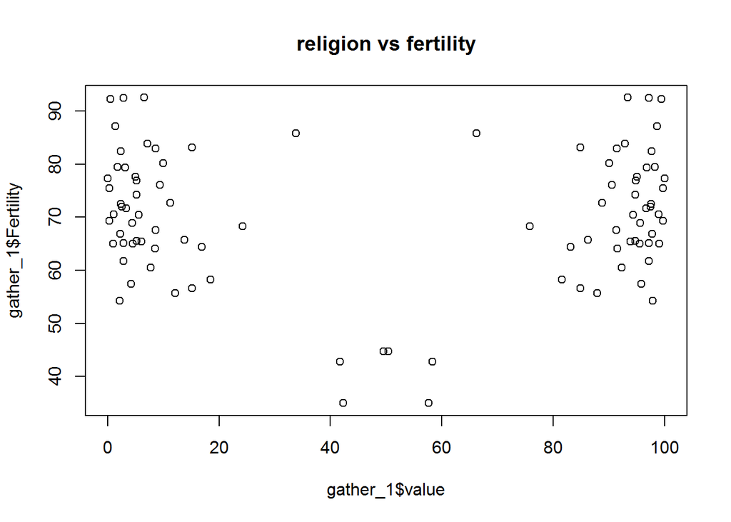

```
##
##  Pearson's product-moment correlation
##
## data:  gather_1$value and gather_1$Fertility
## t = -1.5261e-17, df = 92, p-value = 1
## alternative hypothesis: true correlation is not equal to 0
## 95 percent confidence interval:
##  -0.202617  0.202617
## sample estimates:
##           cor
## -1.591034e-18
```

t = -1.5261 ^-17 df= 92 p-value= 1 Interpretation: Accept H0 i.e.: The religion that a peron chooses does not affect the fertility of the person.

## Question 3

# Crop yield

Null: There is no difference in the crop yields obatined under different conditions Alternative : Treament increases crop yield Type of data: Continuos data Statistical test: Repeated measures Anova Assumptions: 1. The distribution of the data in the population is Gaussian 2. Equal variance across groups 3. The errors are independent 4. Data are unmatched significant level= 0.05

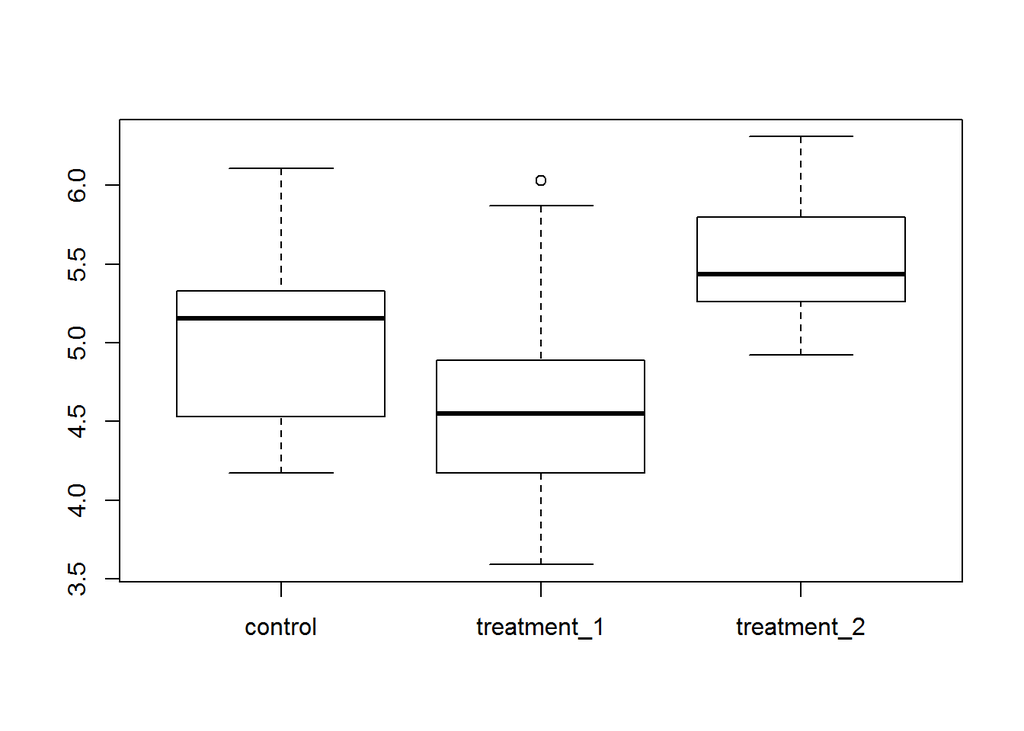

```
##                         Df Sum Sq Mean Sq F value Pr(>F)
## treatment_1              1 0.6409  0.6409   3.710 0.1024
## treatment_2              1 0.8802  0.8802   5.094 0.0648 .
## treatment_1:treatment_2  1 0.5022  0.5022   2.907 0.1391
## Residuals                6 1.0367  0.1728
## ---
## Signif. codes:  0 '***' 0.001 '**' 0.01 '*' 0.05 '.' 0.1 ' ' 1
```

```
##
##  Pairwise comparisons using t tests with pooled SD
##
## data:  question_3$treatment_1 and question_3$treatment_2
##
##      4.92 5.12 5.26 5.29 5.37 5.5 5.54 5.8 6.15
## 5.12 -    -    -    -    -    -   -    -   -
## 5.26 -    -    -    -    -    -   -    -   -
## 5.29 -    -    -    -    -    -   -    -   -
## 5.37 -    -    -    -    -    -   -    -   -
## 5.5  -    -    -    -    -    -   -    -   -
## 5.54 -    -    -    -    -    -   -    -   -
## 5.8  -    -    -    -    -    -   -    -   -
## 6.15 -    -    -    -    -    -   -    -   -
## 6.31 -    -    -    -    -    -   -    -   -
##
## P value adjustment method: holm
```

p-value = 0.1024 (treatment_1) 0.0648 (treatmebt_2) interpretation: accept the H0 i.e.: the condition of the field , does not affect crops yielded by that particular field

## Question 4

# Diets

Null: The type of diet the patients recieved had no influence on the overall disease outcome of the patients. Alernative: The Mediterranean diet resulted in fewer disease outcomes. Type of data: Catergorical, nominal data Statistical test: Chi-squared assumptions: 1.Randomn sampling 2. Independent observations 3. Large sample Statistical significance = 0.05

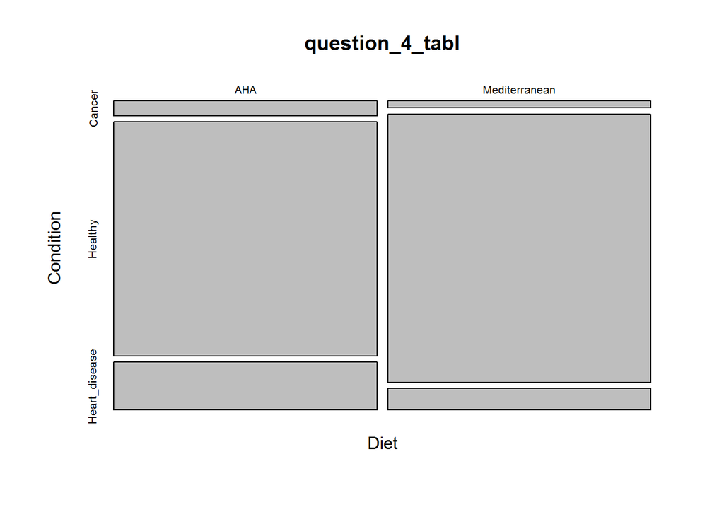

```
##
##  Pearson's Chi-squared test
##
## data:  question_4_tabl
## X-squared = 15.433, df = 2, p-value = 0.0004454
```

X^2 = 15.433 df = 2 p-value = 0.0004454 Interpretation: Reject H0 , i.e.: The diet of the patient influences the overall disease outcomes with the Mediterranean being the better diet.